# Ride Hail Duration Model

## Background

Given training data on trip locations and durations we would like to estimate travel times between two specified locations at a given departure time. Quality of solution would be assessed using mean absolute error of predicted versus actual durations.

## Approach

### Unzipping

Files were downloaded from the Dropbox link provided and unzipped using:  
`$bzip2 -dk test.csv.bz2`  
`$bzip2 -dk train.csv.bz2`

## Exploration

Questions for exploration:

1. How many unique journeys?
2. How many repeat journeys?
3. Average duration?
4. Average distance?
5. In what geography are most journeys occuring?
6. Is there any user data that can be extracted?

```python
print('Unique journeys', df_train.shape[0])
print('Average Duration', np.mean(df_train['duration']), 'secs')
```

```
Unique journeys 12905715
Average Duration 842.141952538 secs
```

### Mapping

We will plot a sample of 100,000 points to get an overview of the data we are looking at. It looks like the data set is for trips around New York City.

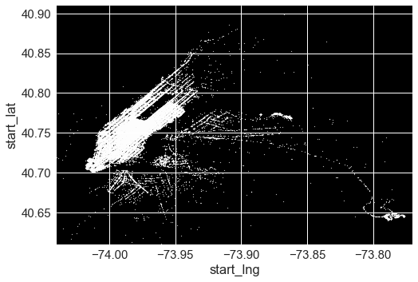

```python
if rerun_analysis_flag == 1:
    P = df_train.sample(100000, replace=False, random_state=seed).plot(kind='scatter', x='start_lng',
                                                                     y='start_lat',color='white'
                                                                     , alpha=.6, s=1,
                                                                    xlim=(-74.04,-73.77),ylim=(40.61, 40.91))
    P.set_facecolor('black') #Background Color
```

### Distribution of Duration

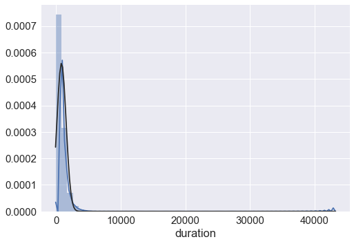

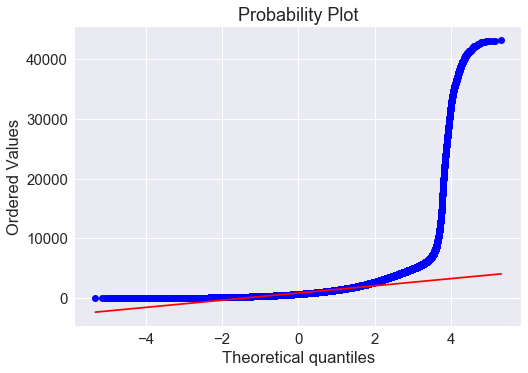

```python
# Distribution of Duration Seconds
if rerun_analysis_flag == 1:
    sns.distplot(df_train['duration'], fit=norm);
    fig = plt.figure()
    res = stats.probplot(df_train['duration'], plot=plt)
```

Here we can see there are some serious outliers in the travel time duration which could affect the model. We will remove these.

Also, we can see from the probability plot that the duration seconds are not normally distributed as the blue points do not follow the red line, so we will apply a log transform to correct for this.

5000 secs is roughly 1hr 23min, so we will remove records with a time greater than this duration. In reality a ride must be greater than 0 sec and we can see there are some rides of 0secs in the data. A reasonable minimum time for a ride is around 1min. So we will remove any rides less than 60sec.

```python
# Remove records with Duration > 5000 seconds
df_train = df_train.loc[ (df_train['duration'] >= 60) & (df_train['duration'] <= 5000) ]
```

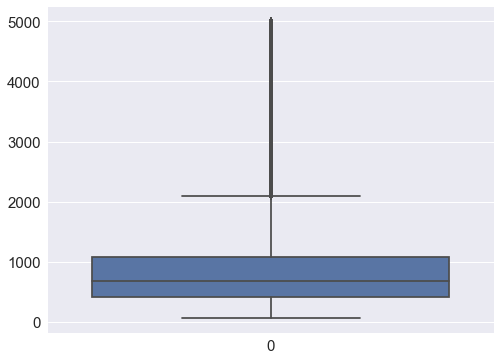

```python
# Check the distribution
# Boxplot
if rerun_analysis_flag == 1:
    f, ax = plt.subplots(figsize=(8, 6))
    fig = sns.boxplot( data=df_train['duration'])
```

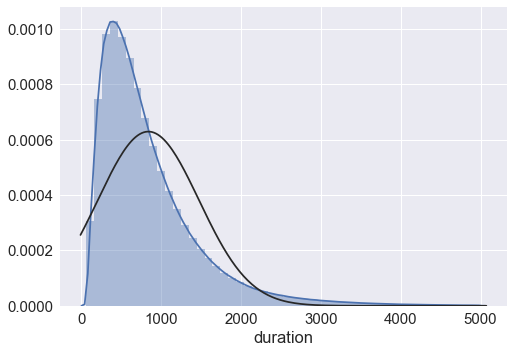

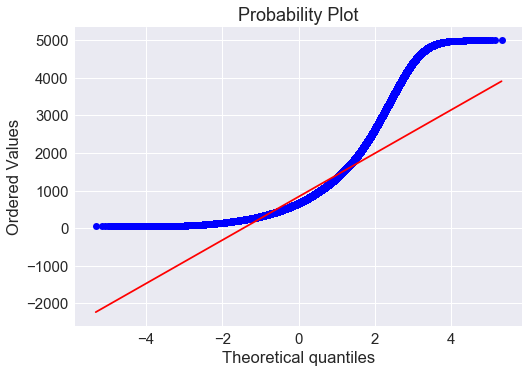

```python
# Check the distribution after removing records with duration > 5000 sec
# Distribution of Duration Seconds
if rerun_analysis_flag == 1:
    sns.distplot(df_train['duration'], fit=norm);
    fig = plt.figure()
    res = stats.probplot(df_train['duration'], plot=plt)
```

```python
#skewness and kurtosis
print("Skewness: %f" % df_train['duration'].skew())
print("Kurtosis: %f" % df_train['duration'].kurt())
```

```
Skewness: 1.971872
Kurtosis: 5.575568
```

It is clear from the histogram of duration that the data has a positive skew and that it is not normally distributed (the black line is the normal distribution).

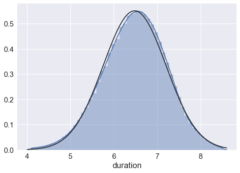

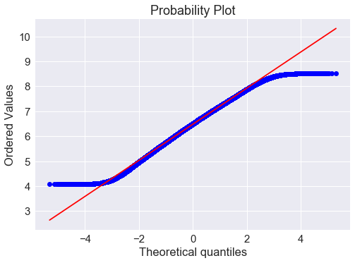

```python
# Apply the log and plot
if rerun_analysis_flag == 1:
    #df_train['duration'] = np.log(df_train['duration'])
    sns.distplot(df_train['duration'], fit=norm);
    fig = plt.figure()
    res = stats.probplot(df_train['duration'], plot=plt)
```

Now duration is approximately normally distributed as can be seen in the histogram and the probability plot where the blue points are now following the red line.

### Missing Data??

Is there any missing data in any of the columns? If so, we will have to address it, by either removing it or imputing it.

```python
if rerun_analysis_flag == 1:
    print('Missing rows in duration' , len(df_train.loc[df_train['duration'].isnull()]) )
    print('Missing rows in start_lng' , len(df_train.loc[df_train['start_lng'].isnull()]) )
    print('Missing rows in start_lat' , len(df_train.loc[df_train['start_lat'].isnull()]) )
    print('Missing rows in end_lng' , len(df_train.loc[df_train['end_lng'].isnull()]) )
    print('Missing rows in end_lat' , len(df_train.loc[df_train['end_lat'].isnull()]) )
    print('Missing rows in start_timestamp' , len(df_train.loc[df_train['start_timestamp'].isnull()]) )
```

```
Missing rows in duration 0
Missing rows in start_lng 0
Missing rows in start_lat 0
Missing rows in end_lng 0
Missing rows in end_lat 0
Missing rows in start_timestamp 0
```

There is no missing data in any of the columns, this means we don't need to remove records or perform any imputation on the data.

Lets take a look at the high level summary statistics of the data frame now....

```python
if rerun_analysis_flag == 1:
    df_train.describe()
```

|  | row_id | start_lng | start_lat | end_lng | end_lat | start_timestamp | duration |
| --- | --- | --- | --- | --- | --- | --- | --- |
| count | 1.281595e+07 | 1.281595e+07 | 1.281595e+07 | 1.281595e+07 | 1.281595e+07 | 1.281595e+07 | 1.281595e+07 |
| mean | 6.451047e+06 | -7.397404e+01 | 4.075075e+01 | -7.397374e+01 | 4.075149e+01 | 1.435376e+09 | 6.480795e+00 |
| std | 3.725654e+06 | 3.735954e-02 | 2.762920e-02 | 3.527811e-02 | 3.172831e-02 | 9.079665e+06 | 7.237966e-01 |
| min | 0.000000e+00 | -7.450384e+01 | 4.036892e+01 | -7.451682e+01 | 4.036887e+01 | 1.420099e+09 | 4.094345e+00 |
| 25% | 3.224157e+06 | -7.399207e+01 | 4.073705e+01 | -7.399143e+01 | 4.073561e+01 | 1.427506e+09 | 6.001415e+00 |
| 50% | 6.450720e+06 | -7.398198e+01 | 4.075363e+01 | -7.398011e+01 | 4.075411e+01 | 1.434865e+09 | 6.504288e+00 |
| 75% | 9.676998e+06 | -7.396783e+01 | 4.076794e+01 | -7.396360e+01 | 4.076908e+01 | 1.443338e+09 | 6.982863e+00 |
| max | 1.290571e+07 | -7.341617e+01 | 4.103082e+01 | -7.341435e+01 | 4.103151e+01 | 1.451635e+09 | 8.517193e+00 |

What about the missing values in the test set?

```python
df_test.isnull().sum()
```

```
row_id             0
start_lng          0
start_lat          0
end_lng            0
end_lat            0
start_timestamp    0
dtype: int64
```

No missing values in test data.

```python
# Lets look at some summary stats
if rerun_analysis_flag == 1:
    df_test.describe()
```

|  | row_id | start_lng | start_lat | end_lng | end_lat | start_timestamp |
| --- | --- | --- | --- | --- | --- | --- |
| count | 1.434344e+06 | 1.434344e+06 | 1.434344e+06 | 1.434344e+06 | 1.434344e+06 | 1.434344e+06 |
| mean | 7.171715e+05 | -7.397387e+01 | 4.075066e+01 | -7.397361e+01 | 4.075142e+01 | 1.435379e+09 |
| std | 4.140596e+05 | 3.790497e-02 | 2.786509e-02 | 3.579871e-02 | 3.188187e-02 | 9.079442e+06 |
| min | 0.000000e+00 | -7.447762e+01 | 4.038432e+01 | -7.447762e+01 | 4.038572e+01 | 1.420099e+09 |
| 25% | 3.585858e+05 | -7.399208e+01 | 4.073701e+01 | -7.399143e+01 | 4.073548e+01 | 1.427508e+09 |
| 50% | 7.171715e+05 | -7.398196e+01 | 4.075357e+01 | -7.398009e+01 | 4.075407e+01 | 1.434866e+09 |
| 75% | 1.075757e+06 | -7.396774e+01 | 4.076793e+01 | -7.396354e+01 | 4.076904e+01 | 1.443343e+09 |
| max | 1.434343e+06 | -7.342264e+01 | 4.102990e+01 | -7.341788e+01 | 4.103128e+01 | 1.451635e+09 |

#### How many of each location are there?

```python
# Intuition
# select start_lng_rd, count(*) from table group by start_lng_rd order by count(*) desc
a = df_train[['start_lng_rnd', 'start_lat_rnd']]
a['location'] = df_train.start_lng_rnd.map(str) + " " + df_train.start_lat_rnd.map(str)
a.head()
```

|  | start_lng_rnd | start_lat_rnd | location |
| --- | --- | --- | --- |
| 0 | -74.009 | 40.714 | -74.009 40.714 |
| 1 | -73.971 | 40.762 | -73.971 40.762 |
| 2 | -73.995 | 40.745 | -73.995 40.745 |
| 3 | -73.991 | 40.750 | -73.991 40.75 |
| 4 | -73.946 | 40.774 | -73.946 40.774 |

```python
a.groupby(['location']).agg(['count']) \
.reset_index(level=('count')) \
.sort_values([('start_lat_rnd', 'count')], ascending=False) \
.head(10)
```

|  | location | start_lng_rnd count | start_lat_rnd count |
| --- | --- | --- | --- |
| 23650 | -73.994 40.751 | 70859 | 70859 |
| 23226 | -73.991 40.75 | 64132 | 64132 |
| 1554 | -73.782 40.645 | 61847 | 61847 |
| 5949 | -73.871 40.774 | 57749 | 57749 |
| 6100 | -73.873 40.774 | 54659 | 54659 |
| 23377 | -73.992 40.75 | 50929 | 50929 |
| 5315 | -73.863 40.769 | 49567 | 49567 |
| 1422 | -73.777 40.645 | 40535 | 40535 |
| 23083 | -73.99 40.757 | 37988 | 37988 |
| 5393 | -73.864 40.77 | 36284 | 36284 |

#### DIFFERENT DATA PREP METHODS

There are many of each location. To find out what works best we need to test each of the cases:

1. Concat start lat + long (do same for end lat+long) and build a model -> `df_train['start_loc'] = df_train.start_lng_rnd.map(str) + " " + df_train.start_lat_rnd.map(str)`
2. Concat start and end points and build model -> `df_train['start_loc'] = df_train.start_lng_rnd.map(str) + " " + df_train.start_lat_rnd.map(str) + " " + df_train.end_lat_rnd.map(str) + " " + df_train.end_lng_rnd.map(str)`
3. Build model without changing the lat/long cols? Mean absolute error: 420.93
4. Build model with rounded lat/long (2 dec place) Mean absolute error: 421.11
5. **Build model with rounded lat/long (3 dec place) Mean absolute error: 409.12**
6. Build model with rounded lat/long (4 dec place) Mean absolute error: 420.95
7. MinMaxScaling the log() target variable made the model worse Mean absolute error: 630.01

### Seasonality

To address seasonality of trip duration in day of year, day of week and time of day, these variables were created from the start_timestamp. This allows the model to take into account traffic caused by holiday events like Christmas/New Year, normal commuter traffic during weekdays and any demand/traffic due to late nights.

```python
# Example
import datetime
timestamp = 1428968089
value = datetime.datetime.fromtimestamp(timestamp)

# day of week
print('Day of Week' , value.weekday())

# hour of day
print('Hour of Day' ,value.strftime('%H'))

# day of year
print('Day of Year' ,value.timetuple().tm_yday)

# month of year
print('Month of Year' ,value.strftime('%m'))
```

```
Day of Week 1
Hour of Day 09
Day of Year 104
Month of Year 04
```

## Ride Distribution by time of day and year

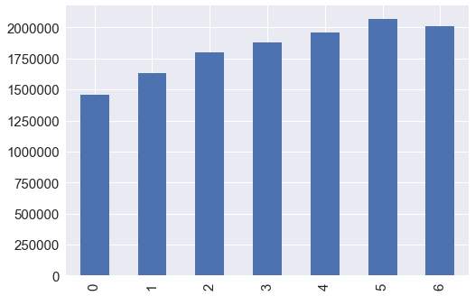

```python
## Make a plot of ride distribution by day of week
if rerun_analysis_flag == 1:
    df_train['day_of_week'].value_counts().sort_index().plot.bar()
```

There are more rides towards the back half of the week. Here 0 is Monday and 6 is Sunday. Friday, Saturday and Sunday see more rides than the first half of the week.

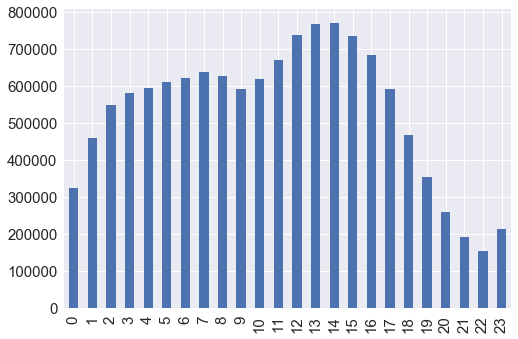

```python
# Distribution of rides by hour of day?
if rerun_analysis_flag == 1:
    df_train['hour_of_day'].value_counts().sort_index().plot.bar()
```

Thre is a double peaked trend to this chart showing a peak in ride demand around 7am and around 1-2pm in the afternoon across the entire data set.

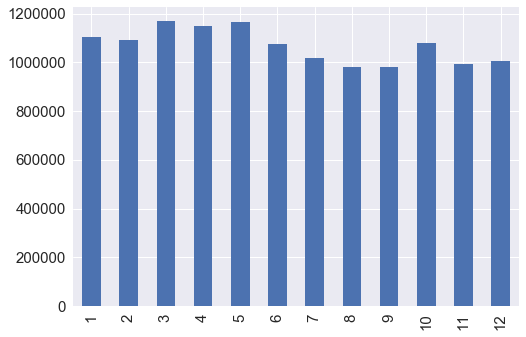

```python
# Distribution of rides by month_of_year?
if rerun_analysis_flag == 1:
    df_train['month_of_year'].value_counts().sort_index().plot.bar()
```

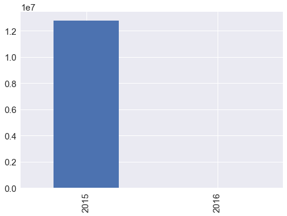

```python
# Distribution of rides by month_of_year?
if rerun_analysis_flag == 1:
    df_train['year'].value_counts().sort_index().plot.bar()
```

### Geospatial Journey Start and End Points

For journey information like this, on previous projects I have setup a PostGIS database and geocoded the the latitude/lonitudes into their respective statistical areas including Block Groups and Blocks. This would allow a grouping of journeys from similar statistical areas (Blocks) to other areas allowing the model to generalise well to unique properties of each journey like traffice conditions, journey routes, etc...

In lieu of doing this I will use an approximation of this method that will have a similar affect. I will group the latitude/longitude pairs into buckets of their 3rd decimal place.

In terms of latitude/longitude this means a rectangle roughly 111 x 111 metres which can be used to identify a large agricultural field or institutional campus (https://gis.stackexchange.com/questions/8650/measuring-accuracy-of-latitude-and-longitude).

## DATA PREP STARTS HERE

#### Data Preparation Steps:

1. impute missing data
2. log scale the target var and others that are not normally distributed
3. center and scale
4. binary encode categoricals
5. Split into train and validation

### Imports, Magics and Defines

```python
# MAGICS
%matplotlib inline

# IMPORTS
import numpy as np # linear algebra
import pandas as pd # data processing, CSV file I/O (e.g. pd.read_csv)
import sklearn.preprocessing as preprocessing
import seaborn as sns
import category_encoders as ce
from sklearn.metrics import mean_squared_error
from sklearn.model_selection import train_test_split, cross_val_score
import xgboost as xgb
from sklearn.cross_validation import KFold
from sklearn.model_selection import RandomizedSearchCV
from sklearn.metrics import mean_absolute_error
import seaborn as sns
import matplotlib.pyplot as plt
import datetime
from scipy.stats import norm
from scipy import stats
import matplotlib
import pickle

# DEFINES
plt.style.use('ggplot')
sns.set(font_scale = 1.5)
seed = 123456
np.random.seed(seed)
```

### Data Loading

```python
df_train = pd.read_csv('data/train.csv')
```

```python
df_test = pd.read_csv('data/test.csv')
```

```python
# Keep the row ids from the test set for when we score the test data and output as csv
test_ids = df_test['row_id']
```

```python
# Flags
rerun_analysis_flag = 0
run_dprep_flag = 1
```

```python
# Drop Row ID as we won't needing this for the model
df_train = df_train.drop('row_id', axis=1)
df_test = df_test.drop('row_id', axis=1)

# Take log of duration
df_train['duration'] = np.log(df_train['duration'])
```

### Distance as the crow flys

```python
from math import sin, cos, sqrt, atan2, radians

def distLatLon(x1, y1, x2, y2):
    # approximate radius of earth in km
    R = 6373.0

    lat1 = radians(x1)
    lon1 = radians(y1)
    lat2 = radians(x2)
    lon2 = radians(y2)

    dlon = lon2 - lon1
    dlat = lat2 - lat1

    a = sin(dlat / 2)**2 + cos(lat1) * cos(lat2) * sin(dlon / 2)**2
    c = 2 * atan2(sqrt(a), sqrt(1 - a))

    distance = R * c

    return distance
```

```python
# # add distance as the crow flies TRAINING
# dist_list = []

# for i in range(0, len(df_train)):
#     dist_list.append( distLatLon(df_train['start_lng'][i], df_train['start_lat'][i], df_train['end_lng'][i], df_train['end_lat'][i]) )

# df_train = df_train.assign(dist=pd.Series(dist_list).values)
```

```python
# add distance as the crow flies
def dist_km(row):
    d = distLatLon(row['start_lng'], row['start_lat'], row['end_lng'], row['end_lat'])
    return d

df_train['distance'] = df_train.apply(dist_km, axis=1)
```

```python
df_test['distance'] = df_test.apply(dist_km, axis=1)
```

|  | start_lng | start_lat | end_lng | end_lat | start_timestamp | distance |
| --- | --- | --- | --- | --- | --- | --- |
| 0 | -73.993111 | 40.724289 | -74.000977 | 40.735222 | 1422173589 | 0.936966 |
| 1 | -73.971924 | 40.762749 | -73.965698 | 40.771427 | 1420567340 | 0.742049 |
| 2 | -73.953247 | 40.765816 | -73.952843 | 40.772453 | 1420567343 | 0.208955 |
| 3 | -73.986618 | 40.739353 | -73.949158 | 40.805161 | 1420103336 | 4.631179 |
| 4 | -73.968864 | 40.757317 | -73.982521 | 40.771305 | 1420690180 | 1.578615 |

### Run from here

```python
# Save Dataframes with distance and duration modified
sub_file = 'pp_train_dist_and_log_dura.csv'
df_train.to_csv(sub_file,index=False)

sub_file = 'pp_test_dist_and_log_dura.csv'
df_test.to_csv(sub_file,index=False)
```

```python
# Round Lat/Long to 3 dec places
dec_pl = 3
df_train = df_train.assign(start_lng_rnd=pd.Series(np.round(df_train['start_lng'], dec_pl) ).values)
df_train = df_train.assign(start_lat_rnd=pd.Series(np.round(df_train['start_lat'], dec_pl) ).values)
df_train = df_train.assign(end_lng_rnd=pd.Series(np.round(df_train['end_lng'], dec_pl) ).values)
df_train = df_train.assign(end_lat_rnd=pd.Series(np.round(df_train['end_lat'], dec_pl) ).values)
```

```python
df_train = df_train.drop(['start_lng', 'start_lat', 'end_lng', 'end_lat'], axis=1)
```

Now for the test set...

```python
# Round Lat/Long to 3 dec places
df_test = df_test.assign(start_lng_rnd=pd.Series(np.round(df_test['start_lng'], dec_pl) ).values)
df_test = df_test.assign(start_lat_rnd=pd.Series(np.round(df_test['start_lat'], dec_pl) ).values)
df_test = df_test.assign(end_lng_rnd=pd.Series(np.round(df_test['end_lng'], dec_pl) ).values)
df_test = df_test.assign(end_lat_rnd=pd.Series(np.round(df_test['end_lat'], dec_pl) ).values)
```

```python
df_test = df_test.drop(['start_lng', 'start_lat', 'end_lng', 'end_lat'], axis=1)
```

```python
## Apply transformations to entire dataframe
run_dprep_flag = 1
if run_dprep_flag == 1:
    # Apply to Data Frame
    df_train['day_of_week'] = df_train['start_timestamp'].apply(lambda x: datetime.datetime.fromtimestamp(x).weekday())
    df_train['hour_of_day'] = df_train['start_timestamp'].apply(lambda x: datetime.datetime.fromtimestamp(x).timetuple().tm_hour)
    df_train['day_of_year'] = df_train['start_timestamp'].apply(lambda x: datetime.datetime.fromtimestamp(x).timetuple().tm_yday)
    df_train['month_of_year'] = df_train['start_timestamp'].apply(lambda x: datetime.datetime.fromtimestamp(x).timetuple().tm_mon)
    #df_train['year'] = df_train['start_timestamp'].apply(lambda x: datetime.datetime.fromtimestamp(x).timetuple().tm_year)

    df_train = df_train.drop('start_timestamp', axis=1)
    now = datetime.datetime.now()
    sub_file = 'lyft_preprocessed_'  + str(now.strftime("%Y-%m-%d-%H-%M")) + '.csv'
    df_train.to_csv(sub_file,index=False)
```

Now for the test set...

```python
## Apply transformations to entire dataframe
if run_dprep_flag == 1:
    # Apply to Data Frame
    df_test['day_of_week'] = df_test['start_timestamp'].apply(lambda x: datetime.datetime.fromtimestamp(x).weekday())
    df_test['hour_of_day'] = df_test['start_timestamp'].apply(lambda x: datetime.datetime.fromtimestamp(x).timetuple().tm_hour)
    df_test['day_of_year'] = df_test['start_timestamp'].apply(lambda x: datetime.datetime.fromtimestamp(x).timetuple().tm_yday)
    df_test['month_of_year'] = df_test['start_timestamp'].apply(lambda x: datetime.datetime.fromtimestamp(x).timetuple().tm_mon)
    #df_test['year'] = df_test['start_timestamp'].apply(lambda x: datetime.datetime.fromtimestamp(x).timetuple().tm_year)

    df_test = df_test.drop('start_timestamp', axis=1)
    now = datetime.datetime.now()
    sub_file = 'lyft_preprocessed_testset'  + str(now.strftime("%Y-%m-%d-%H-%M")) + '.csv'
    df_test.to_csv(sub_file,index=False)
```

```python
## Min Max scale Train
scaler = preprocessing.MinMaxScaler((0,1), copy=True)

# all cols except target variable
target_var = 'duration'
mycols = df_train.drop(target_var, axis=1).columns.values.tolist()

# # Specific Columns
scaler.fit(df_train[mycols] )
df_train[mycols] = scaler.transform(df_train[mycols] )

## MIN MAX SCALE TEST SET
scaler.fit(df_test[mycols] )
df_test[mycols] = scaler.transform(df_test[mycols] )
```

### SCALE ROW WEIGHTS TO BE INVERSE TO FREQUENCY

```python
b = df_train[['hour_of_day','month_of_year']].groupby('hour_of_day').agg('count')
bb = np.round(1 // (b['month_of_year'] / b['month_of_year'].sum()) )
```

```python
# Make the Weights Dictionary
cc = pd.DataFrame(bb)
hours = cc.index.values
weights = [int(n) for n in cc.month_of_year.values]
weights_dict = dict(zip(hours, weights))
```

```python
# Now apply the dict to the entire dataset
df_train['weight'] = df_train['hour_of_day'].apply(lambda x: weights_dict[x])
```

### SAVE AS CSV (OLD)

```python
# Save Dataframes with distance and duration modified
# sub_file = 'pp_train_dist_log_yrMthDay_weights.csv'
# df_train.to_csv(sub_file,index=False)

# sub_file = 'pp_test_dist_log_yrMthDay_weights.csv'
# df_test.to_csv(sub_file,index=False)
```

### SAVE AS PICKLE

```python
# Pickle Data
import pickle

# Training
sub_file = 'pp_train_dist_log_yrMthDay_weights.p'
pickle.dump( df_train, open( sub_file, "wb" ) )

# Testing
sub_file = 'pp_test_dist_log_yrMthDay_weights.p'
pickle.dump( df_test, open( sub_file, "wb" ) )
```

```python
## Pickle test_ids so we dont have to load test.csv
sub_file = 'test_ids.p'
pickle.dump( test_ids, open( sub_file, "wb" ) )
```

# Load Data and Start Here!

```python
## LOAD PICKLE
df_train = pickle.load( open( 'pp_train_dist_log_yrMthDay_weights.p', "rb" ) )
df_test = pickle.load( open( 'pp_test_dist_log_yrMthDay_weights.p', "rb" ) )
test_ids = pickle.load( open( 'test_ids.p', "rb" ) )
```

```python
## CSV
# df_train = pd.read_csv('pp_train_dist_log_yrMthDay_weights.csv')
# df_test = pd.read_csv('pp_test_dist_log_yrMthDay_weights.csv')
```

### Split into train / validation sets

```python
from sklearn.metrics import mean_squared_error
from sklearn.model_selection import train_test_split

y = df_train['duration'].values
X = df_train.drop(['duration','weight'], axis=1).as_matrix() # Drop the target duration column and the weight column to make the feature set
W = df_train['weight'].values

# Validation Set Size 20%
val_size = 0.2

X_train, X_val, y_train, y_val = train_test_split(
    X, y, test_size=val_size, random_state=seed
)
print('Done')
```

```
Done
```

### Baseline Model

Create a linear regression model as a baseline to compare our model performance to.

```python
from sklearn import linear_model

# Create linear regression object
regr = linear_model.LinearRegression()

# Train the model using the training sets
regr.fit(X_train, y_train)

# The coefficients
print('Coefficients: \n', regr.coef_)
# The mean squared error
print("Mean absolute error: %.2f"
      % np.mean(  np.abs( np.exp(  regr.predict(X_val) ) - np.exp(y_val) ) ) )
# Explained variance score: 1 is perfect prediction
print('Variance score: %.2f' % np.exp(regr.score(X_val, y_val) ) )
```

```
Coefficients:
 [ 10.20963662  -3.17668482   0.36437528  -1.59211334  -0.38876169
   0.11306803  -0.22362831  -0.07354767   0.13381736]
Mean absolute error: 430.10
Variance score: 1.41
```

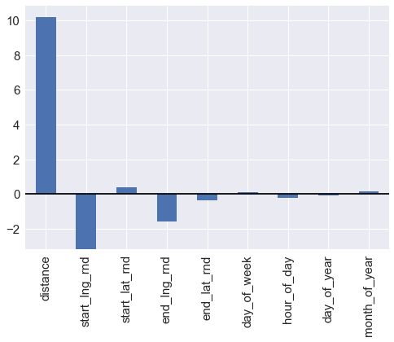

```python
var_weights = pd.DataFrame(df_train.drop(['duration','weight'], axis=1).columns.tolist(), columns=['feature'])
var_weights['coeff'] = regr.coef_
#var_weights.plot.bar()

ax = var_weights.coeff.plot.bar(rot=90)
ax.set_xticklabels(var_weights.feature)
plt.axhline(0, color='k')
```

If the next model is able to beat the MAE of this linear model then we will be happy.

## Build Model

### GBM 3

Lets run the GBM with 10 iterations again, this time with a higher learning rate

```python
from sklearn import ensemble
if rerun_analysis_flag == 1:
    params = {'n_estimators': 10, 'max_depth': 4, 'min_samples_split': 2,
              'learning_rate': 0.1, 'loss': 'ls'}
    clf = ensemble.GradientBoostingRegressor(**params)

    clf.fit(X_train, y_train) # , sample_weight=X_train[:,5])
    mse = mean_absolute_error(np.exp(y_val), np.exp(clf.predict(X_val) ))
    print("MSE: %.4f" % mse)

    # compute test set deviance
    test_score = np.zeros((params['n_estimators'],), dtype=np.float64)

    for i, y_pred in enumerate(clf.staged_predict(X_val)):
        test_score[i] = clf.loss_(y_val, y_pred)
```

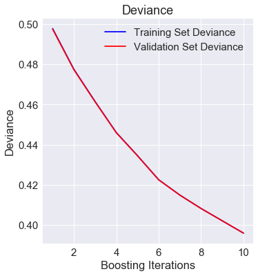

```python
if rerun_analysis_flag == 1:
    plt.figure(figsize=(12, 6))
    plt.subplot(1, 2, 1)
    plt.title('Deviance')
    plt.plot(np.arange(params['n_estimators']) + 1, clf.train_score_, 'b-',
             label='Training Set Deviance')
    plt.plot(np.arange(params['n_estimators']) + 1, test_score, 'r-',
             label='Validation Set Deviance')
    plt.legend(loc='upper right')
    plt.xlabel('Boosting Iterations')
    plt.ylabel('Deviance')
```

Since the train and validation set's deviance have not separated, this model could be run for more estimators. A recommended number of estimators would be around 500.

```python
column_names = pd.DataFrame(list(df_train)[1:])
```

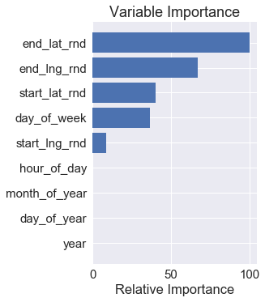

```python
if rerun_analysis_flag == 1:
    feature_importance = clf.feature_importances_
    # make importances relative to max importance
    feature_importance = 100.0 * (feature_importance / feature_importance.max())
    sorted_idx = np.argsort(feature_importance)
    pos = np.arange(sorted_idx.shape[0]) + .5
    plt.subplot(1, 2, 2)

    column_names['idx'] = sorted_idx
    column_names.columns = ['variable', 'idx']
    cols = column_names.sort_values(by=['idx'], axis=0, ascending=True)

    plt.barh(pos, feature_importance[sorted_idx], align='center')
    #plt.yticks(pos, df_train.feature_names[sorted_idx])
    plt.yticks(pos, cols['variable'])
    plt.xlabel('Relative Importance')
    plt.title('Variable Importance')
    plt.show()
```

The variable importance for this model indicates that the most important variables in predicting the travel time between two locations is the start and end point latitude and longitude along with the day of the week that the trip is taken.

### XGBOOST with 5-Fold Cross Validation

```python
import xgboost as xgb
```

```python
col_names = df_train.columns[1:10].values.tolist() # duration is column 0
```

```python
def xgboost(X, y, X_sub, col_names, test_ids): #, W): # uncomment to add weights
    # Turn X_sub into a D matrix
    xg_sub = xgb.DMatrix(X_sub, feature_names=col_names)

    num_folds = 5
    num_estr = 100
    stopping = 10

    shift = 0
    ind_params = {'n_estimators':5,
                  'max_depth':5,
                  'seed':seed,
                  'objective':'reg:linear',
                  'eval_metric':'mae',
                  'silent':0}

    kf = KFold(X.shape[0], n_folds = num_folds)

    for i,(train_idx, valid_idx) in enumerate(kf):
        print('Fold %d \n' %(i+1))
        xx_train, xx_val = X[train_idx-1], X[valid_idx-1]
        yy_train, yy_val = y[train_idx-1], y[valid_idx-1]
        ww_train, ww_val = W[train_idx-1], W[valid_idx-1]

        dtrain = xgb.DMatrix(xx_train, label=yy_train, feature_names=col_names) #, weight = ww_train)
        dvalid = xgb.DMatrix(xx_val, label=yy_val, feature_names=col_names) #, weight = ww_val)
        watchlist = [(dtrain,'train'), (dvalid,'validation')]

        clf = xgb.train(ind_params, dtrain, num_estr, watchlist, early_stopping_rounds = stopping)

        score = clf.predict(dvalid, ntree_limit=clf.best_ntree_limit )

        cv_score = mean_absolute_error(np.exp(yy_val),np.exp(score))

        print('MAE %0.4f' %(cv_score))
        y_pred = np.exp(clf.predict(xg_sub, ntree_limit = clf.best_ntree_limit)) - shift

        if i>0:
            fpred = pred+y_pred
        else:
            fpred = y_pred

        pred = fpred

    print('KFold Finished ....')
    y_pred = fpred / num_folds

    now = datetime.datetime.now()
    sub_file = 'duration_'  + str(now.strftime("%Y-%m-%d-%H-%M")) + '.csv'

    #pd.DataFrame({'row_id':test_ids,'duration':y_pred}).to_csv(sub_file,index=False)
    out = pd.DataFrame({'row_id':test_ids,'duration':y_pred})
    out[['row_id', 'duration']].to_csv(sub_file,index=False)

    return y_pred, dvalid, clf
```

```python
w = (293.0379, 273.1350, 277.3356, 271.8558, 249.4153)
print('Model Submitted MAE', np.mean(w) )
```

```
Model Submitted MAE 272.95592
```

```python
w = (225.8536, 243.9017, 252.0477, 245.0679, 267.8248 )
print('Model with distance MAE', np.mean(w) )
```

```
Model with distance MAE 246.93914
```

```python
w = (227.8835,246.4657, 254.5008, 246.3942, 267.4517  )
print('Model with weights MAE', np.mean(w) )
```

```
Model with weights MAE 248.53918
```

```python
w = (217.7265, 210.3023, 213.5179, 211.8090)
print('Model 100 estimators', np.mean(w) )
print( 'Improvement over submitted model' ,( 272.95592 - np.mean(w))/272.95592 )
```

```
Model 100 estimators 213.338925
Improvement over submitted model 0.218412537087
```

```python
xgb_1_preds, dvalid, model = xgboost(X, y, df_test, col_names, test_ids)
```

```
Fold 1

Multiple eval metrics have been passed: 'validation-mae' will be used for early stopping.

Will train until validation-mae hasn't improved in 10 rounds.
Stopping. Best iteration:

MAE 217.7265
Fold 2

Multiple eval metrics have been passed: 'validation-mae' will be used for early stopping.

Will train until validation-mae hasn't improved in 10 rounds.
MAE 210.3023
Fold 3

Multiple eval metrics have been passed: 'validation-mae' will be used for early stopping.

Will train until validation-mae hasn't improved in 10 rounds.
MAE 213.5179
Fold 4

Multiple eval metrics have been passed: 'validation-mae' will be used for early stopping.

Will train until validation-mae hasn't improved in 10 rounds.
MAE 211.8090
Fold 5

Multiple eval metrics have been passed: 'validation-mae' will be used for early stopping.

Will train until validation-mae hasn't improved in 10 rounds.
```

### XGBOOST Variable Importance

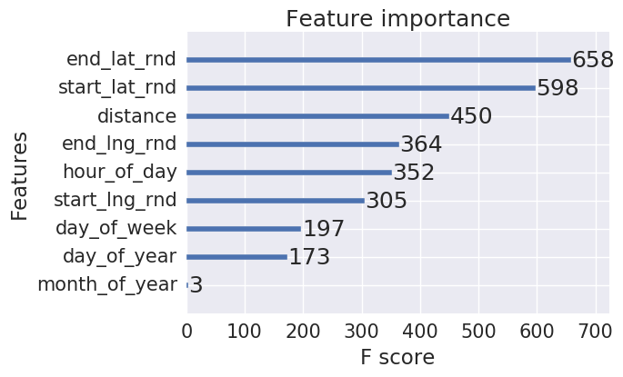

```python
# fig, ax = plt.subplots(figsize=(15, 15)) # adjust plot size
xgb.plot_importance(model)
```

### Weight conculsions

When adding hour_of_day weights into the model the hour_of_day became more important in predicting the duration.

This leads us to think that the other variables (day_of_week, day_of_year, month_of_year) do not contain as much relevant information or their features require a different type of engineering, for instance one-hot or binary encoding.

## Conculsion

- The XGboost model had the lowest MAE and was used to create the submission file duration.csv
- The most important variables in predicting the duration seconds were start/end latitude and longitude and the hour of the day
- This makes sense from a practical perspective as the duration of the Lyft ride will be dependent on the distance from point A to B, the geographic and traffic conditions of the start and end points and the hour of the day that you take the ride

## Real Time Considerations

For a real time implementation in a mobile app the computational overhead would not be too large. It would only require the weights from the trained model and the feature engineering pipeline, both of which are quite small in this case. The feature engineering just consists of a rounding process and some datetime operations. Libraries to implement this sort of model on iOS and Android currently exist and there is further opportunity to use a deep learning approach as Tensorflow Lite just became available at the time of writing, which works on iOS and Android.

## Improvements

This model could be improved through a number of tweaks to the dataset and the model itself. Including:

# Bonus Round - Deep Learning

```python
from keras.models import Sequential
from keras.callbacks import EarlyStopping, ModelCheckpoint
from keras.layers import Dense, Activation, Dropout
from keras import optimizers
print('Done')
```

```
Done
```

```python
## Roll your own metric
import keras.backend as K

def mae(y_true, y_pred):
    return K.mean( K.abs( K.exp(y_true) - K.exp(y_pred) ) )
```

```python
epochs = 12
learn_rate = 0.01
batch_size= 256
dropout = 0.2
init_mean = 0.0
init_stdev = 0.05
```

```python
m = Sequential()
m.add(Dense(512, activation='relu', input_shape=(X.shape[1],)))
m.add(Dropout(dropout))
m.add(Dense(256, activation='relu'))
m.add(Dropout(dropout))
m.add(Dense(128, activation='relu'))
m.add(Dropout(dropout))
m.add(Dense(1, activation=None))  # linear activation for regression

m.compile(
    optimizer=optimizers.Adam(lr=learn_rate),
    loss='mean_absolute_error',
    metrics=[mae]
)
```

```python
print('Starting training....')

m.fit(
    # Feature matrix
    X_train,
    # Target class one-hot-encoded
    y_train,
    # Iterations to be run if not stopped by EarlyStopping
    nb_epoch=epochs,
    callbacks=[
        # Stop iterations when validation loss has not improved
        EarlyStopping(monitor='val_loss', patience=25),
        # Nice for keeping the last model before overfitting occurs
        ModelCheckpoint(
            'best.model',
            monitor='val_loss',
            save_best_only=True,
            verbose=1
        )
    ],
    #verbose=2,
    validation_split=0.1,
    batch_size=batch_size
)
print('Done')
```

```
Starting training....
Train on 9292114 samples, validate on 1032458 samples
Done
```

```python
## Check Error
m.load_weights("best.model")

mae = mean_absolute_error( np.exp(y_val), np.exp( m.predict(X_val) ))
print('MAE', mae)
```

```
MAE 230.545337491
```

### Deep Learning Conclusion

The deep learning network was not any better than K-folds cross validation with gradient boosted trees and it took longer to train even using a GPU. MAE DL=230.55 vs XGB=213.34